# Assessment of different PFS endpoints in the context of Murano Trials

Zhipeng Wang

11/27/2017

## Motivation

The motivation of the study is to perform Assessment of different PFS endpoints, with a particular focus on comparing the ALC-based lab data between the Flatiron and the Murano trial arms. The goal is to assess whether or not ALC-based measurements can serve as a good PFS endpoint in real-world data.

Murano (NCT02005471) is an open-label, multicenter, randomized, Phase III study to investigate the efficacy and safety of venetoclax in combination with rituximab (venetoclax+R) compared with bendamustine in combination with rituximab (BR) in participants with relapsed or refractory chronic lymphocytic leukemia (CLL). Participants are randomly assigned in 1:1 to receive either venetoclax+R (Arm A) or BR (Arm B).

There is an interest to explore if the methodology previously applied in solid tumors can be extended to trials on haematological malignancies with primary outcome “progression-free survival” (PFS). While the use of matching procedures for creating synthetic controls is reasonably well understood, the use of the PFS and its proxy ALC-PFS as endpoints is novel and needs to be validated.

First of all, we notice that the ALC measurement frequencies between the Murano trial data and Flatiron data are different. There are primarily two ways to mitigate and normalize the measurement frequencies:

- Use the Interpolation Method to normalize the ALC measurement frequencies between the Murano trial and the Flatiron Data
- Use Smoothing Spline (e.g. B-spline) to smoothing the original data

### Comparison of PFS endpoints

The overall objective here is to gain trust in the results of a comparison that uses ALC-based PFS in place of IA-PFS. Two slightly different ALC-based PFS variables (ALC-PFS and ALC2-PFS) are defined in order to understand better the impact of a particular detail in the FI algorithm to detect progression events.

**Bias in OS outcomes when using ALC-based vs IA-PFS**

```r
warning("delete this later, and use data from earlier")
library(RocheTeradata)
RocheTeradata::tdRWDSconnect(datalab = FALSE, pwd = readLines("~/.ssh/.tdpass"), uid = "wangz119")
d_alc <- tdRWDSquery("SELECT * FROM RWDS_rwds_1040.derived_fulldataset")
```

```r
install.packages("rms")
library(rms)
library(survival)
load(file="d_alc.RData")
d_alc$SurvObj <- with(d_alc, Surv(timetoOS, eventOS == 1))
km.by.StudyArm <- npsurv(formula = Surv(timetoOS, eventOS ==1) ~ StudyArm, data = d_alc)
class(km.by.StudyArm)
```

```
## [1] "npsurv"  "survfit"
```

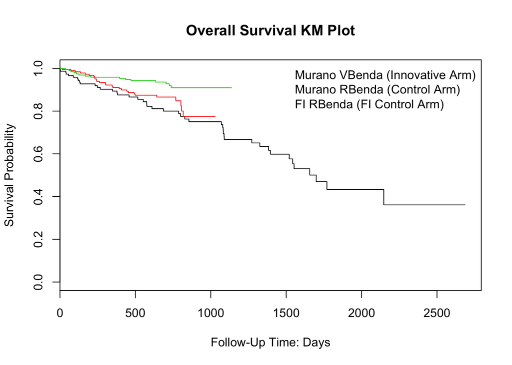

```r
N <- length(unique(d_alc$StudyArm))
plot(km.by.StudyArm, xlab="Follow-Up Time: Days",ylab="Survival Probability", mark.time = F,
col=1:N, main = "Overall Survival KM Plot")
legend(
  "topright",
  legend=c("Murano VBenda (Innovative Arm)", "Murano RBenda (Control Arm)", "FI RBenda (FI Control Arm)"),
  col=1:N,
  horiz=FALSE,
  bty='n')
```

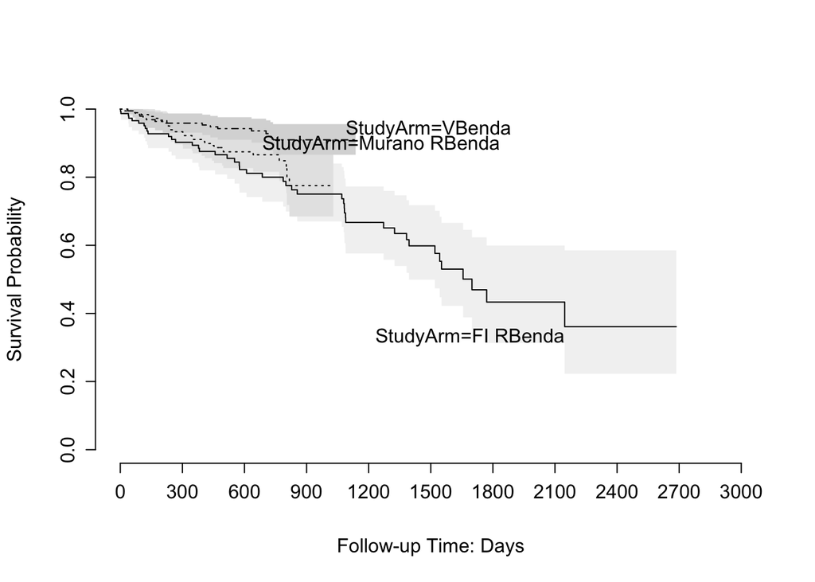

```r
survplot(km.by.StudyArm, title = 'Overall Survival Endpoints', xlab = "Follow-up Time: Days")
```

```r
d_alc$SurvObj_TTNT <- with(d_alc, Surv(timetoTTNT, eventTTNT == 1))
kmTTNT.by.StudyArm <- npsurv(formula = Surv(timetoTTNT, eventTTNT == 1) ~ StudyArm, data = d_alc)
class(kmTTNT.by.StudyArm)
```

```
## [1] "npsurv"  "survfit"
```

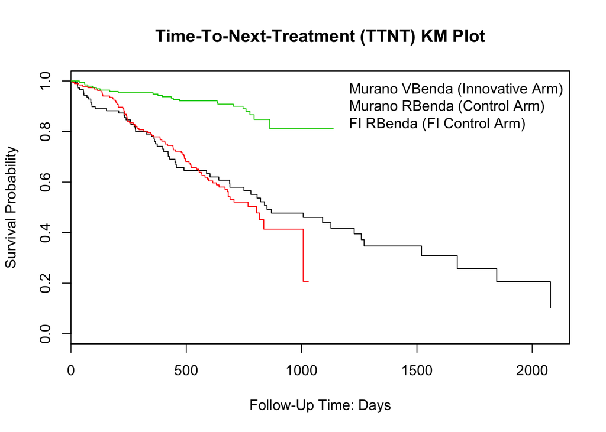

```r
plot(kmTTNT.by.StudyArm, xlab="Follow-Up Time: Days",ylab="Survival Probability", mark.time = F,
col=1:N, main = "Time-To-Next-Treatment (TTNT) KM Plot")
legend(
  "topright",
  legend=c("Murano VBenda (Innovative Arm)", "Murano RBenda (Control Arm)", "FI RBenda (FI Control Arm)"),
  col=1:N,
  horiz=FALSE,
  bty='n')
```

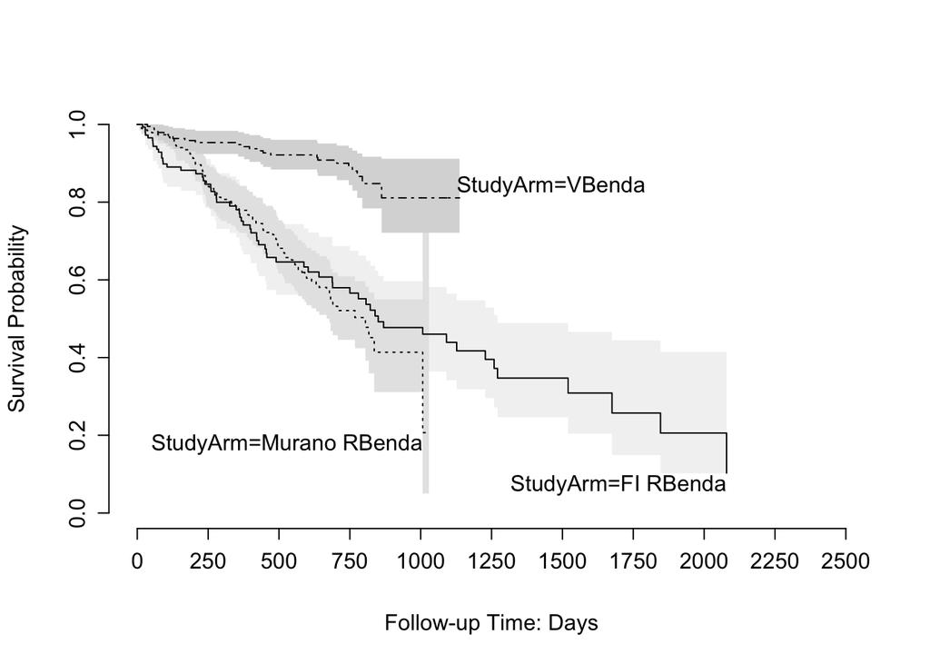

```r
survplot(kmTTNT.by.StudyArm, xlab = "Follow-up Time: Days")
```

### Comparison of the ALC-lab data between the Marano Trial and the Flatiron Data

In Flatiron, ALC-based measurement is the only PFS endpoint used to indicate CLL progression. In Murano trials, the Investigator-assessed PFS was the primary endpoint. A PFS-event was defined as death pr progression-assessed according to standard iwCLL guidelines (Hallek et al. 2008). Raw ALC values are also available in the trial data.

```r
load(file="d_alc_count.RData")
summary(d_alc_count)
```

```
##     PatID           TestResultCleaned    StudyArm
##  Length:45638       Min.   :    0.00   Length:45638
##  Class :character   1st Qu.:    0.87   Class :character
##  Mode  :character   Median :    1.80   Mode  :character
##                     Mean   :   14.23
##                     3rd Qu.:    8.50
##                     Max.   :31969.00
##                     NA's   :4292
##    DaysToLab
##  Min.   :-2686.00
##  1st Qu.:   -4.00
##  Median :   43.00
##  Mean   :   98.91
##  3rd Qu.:  246.00
##  Max.   : 3658.00
##  NA's   :13862
```

```r
library(dplyr)
d_alc_count %>%
  group_by(StudyArm) %>%
  summarise(
    Patients = n_distinct(PatID),
    Labs = n(),
    Missing = sum(is.na(TestResultCleaned)),
    `Lab range` = paste(round(range(TestResultCleaned, na.rm = TRUE)),collapse = " to ")
  ) %>%
  knitr::kable(
    caption = "Summary of the ALC labs"
  )
```

Summary of the ALC labs

| StudyArm | Patients | Labs | Missing | Lab range |
| --- | --- | --- | --- | --- |
| FI RBenda | 577 | 27922 | 2861 | 0 to 31969 |
| Murano RBenda | 195 | 6207 | 707 | 0 to 536 |
| VBenda | 194 | 11509 | 724 | 0 to 790 |

### Including Plots of Raw Data

Plots of raw ALC lab data for Murano Trial Arms and Flatiron, for example:

```r
install.packages("ggthemes")
```

[figure not shown]

```r
library(ggplot2)
library(ggthemes)
```

### Smoothing Splines

We plan to use 1. Kernel Smoothing. 2. Smoothing Splines. 3. Spline models for observational data. to smooth out the original lab data. Good references are Z.Wang and D.W.Scott (Journal of American Statistical Association, 2017, in press), Grace Wahba (Spline Models for Observational Data, Springer. 1987).

```r
# This module uses the smoothing spline and functional pca method to analyze ALC lab data
install.packages("pspline")
library(pspline)
library(reshape2)

smP <- function(formula,data,...){
  M <- model.frame(formula, data)
  sm.spline(x =M[,4],y =M[,2])

}

install.packages("ggthemes")
library(ggplot2)
library(ggthemes)
require(mgcv)
d_alc_count %>%
  # filter to 30 days before, 600 days after
  filter(DaysToLab >= -30 & DaysToLab <= 600 & StudyArm != "FI RBenda" & StudyArm != "VBenda" & StudyArm != "Murano RBenda") %>%
  na.omit() %>%
  # if the ALC measurement value is below 0.1 or is above 10, recode and colour
  mutate(
    colour = case_when(
      .$TestResultCleaned < 0.1 | .$TestResultCleaned > 10 ~ "red",
      TRUE ~ "blue"
    ),
    TestResultCleaned = case_when(
      .$TestResultCleaned < 0.1  ~ 0.1,
      .$TestResultCleaned > 10 ~ 10,
      TRUE ~ .$TestResultCleaned
    )
  ) %>%
  ggplot(
    aes(x = DaysToLab, y = TestResultCleaned, group = PatID)
  ) +
  geom_line(
    alpha = 0.2
  ) +
  geom_jitter(
    data = . %>% filter(colour == "red"),
    aes(colour = colour),
    height = 0.2, alpha = 0.2
  ) +
  #scale_y_log10() +
  ggthemes::theme_hc() +
  facet_grid(StudyArm ~ .) +
  labs(
    title = "ALC labs present in the trial",
    x = "Days from exposure",
    y = "ALC (10^9/L)",
    subtitle = "Filtered to labs -30 to 600 days after R-Benda exposure starts."
  ) #+
  #stat_smooth(method=smP, se=FALSE, formula=y ~ x, size = 1)
  #geom_smooth(method="loess", formula=y ~ x, se=FALSE)


d_alc_FI <- d_alc_count %>% filter(DaysToLab >= -30 & DaysToLab <= 600 & StudyArm == "Flatiron") %>%
  na.omit()

d_alc_VR <- d_alc_count %>% filter(DaysToLab >= -30 & DaysToLab <= 600 & StudyArm == "GDC0199+RITUXIMAB") %>% na.omit()

d_alc_BR <- d_alc_count %>% filter(DaysToLab >= -30 & DaysToLab <= 600 & StudyArm == "BENDAMUSTINE+RITUXIMAB") %>% na.omit()

P_FI = unique(d_alc_FI$PatID)
P_VR = unique(d_alc_VR$PatID)
P_BR = unique(d_alc_BR$PatID)

## Use a list to store results
C <- list()
j=1
for (i in 1:length(P_FI)) {

  temp_alc <- d_alc_FI %>% filter (PatID == P_FI[i])
  #assign(paste0("temp_alc_", i), d_alc_FI %>% filter(PatID == P_FI[i]))
  if (nrow(temp_alc) <=20) next
  C[[j]] = temp_alc
  j = j+1
}

a_data <- C[[1]]
for (i in 2:length(C)){
  a_data <- rbind(a_data, C[[i]])
}

for (i in 1:length(C)){
plot(smooth.spline(C[[1]]$DaysToLab, C[[1]]$TestResultCleaned, df=6), lty=2, col="blue")
lines(smooth.spline(C[[1]]$DaysToLab, C[[1]]$TestResultCleaned, df=6), lty=2, col="red")
}

plot(smooth.spline(C[[2]]$DaysToLab, C[[2]]$TestResultCleaned, df=8), lty=2, col="blue")
lines(smooth.spline(C[[2]]$DaysToLab, C[[2]]$TestResultCleaned, df=8), lty=2, col="red")

plot(smooth.spline(C[[4]]$DaysToLab, C[[4]]$TestResultCleaned, df=10), lty=2, col="blue")
lines(smooth.spline(C[[4]]$DaysToLab, C[[4]]$TestResultCleaned, df=10), lty=2, col="red")
```

[output not shown]

### Nonparametric Two-sample Hypothesis Testing (Kolmogorov-Smirnov test)

Using Kolmogorov-Smirnov two-sample test to examine if two samples come from the same distribution. The tentative plan is to compare every data point (each patient’s ALC-measurement data) and run a goodness-of-fit test.

```r
ks.test(x, y)
```